# Assignment 2

Author

Sofija Kaluderovic

Published

February 16, 2024

# 1 Question 1

Suppose you have a dataframe called students with three columns: name, age, and grade. Write a function called increase_grade that takes a dataframe and a percentage increase as input, and returns a new dataframe where the grade column has been increased by the specified percentage for all students.

```r
# Sample dataframe
students <- data.frame(
  name = c("Alice", "Bob", "Charlie"),
  age = c(20, 21, 22),
  grade = c(80, 75, 100)
)
# Defining a function that will take the grades from the dataframe and the percentage increase in grades as inputs and calculate the new grades
increase_grade <- function(grade,percentage_increase){
    new_grade <- students$grade * (1 + percentage_increase / 100)
  return(new_grade)
  }
percentage_increase <- 10
# Creating a new column in our dataframe that will store in itself new grades calculated by the function
students$new_grade <- increase_grade(students$grade, percentage_increase)
students
```

```
     name age grade new_grade
1   Alice  20    80      88.0
2     Bob  21    75      82.5
3 Charlie  22   100     110.0
```

# 2 Question 2

Create a function employee_performance_analysis that takes the two datasets as inputs and performs the following tasks:

Step1: Merge employee_data with performance_data based on the employee_id.

Step2: Calculate a new column performance_grade based on the following criteria:

If rating is greater than or equal to 4, assign “High”. If rating is between 3 and 4, assign “Medium”. If rating is less than 3, assign “Low”. Step3: Return the merged dataset with the added performance_grade column.

```r
# Sample data for employee_data
employee_data <- data.frame(
  employee_id = c(101, 102, 103, 104, 105),
  name = c("Alice", "Bob", "Charlie", "David", "Eve"),
  department = c("HR", "Finance", "Marketing", "IT", "Operations")
)
# Sample data for performance_data
performance_data <- data.frame(
  employee_id = c(101, 102, 103, 104, 105),
  rating = c(4.5, 3.2, 2.9, 4.8, 3.7),
  bonus = c(1000, 800, 500, 1200, 900)
)
library("dplyr")
# Creating function that will take the two dataframes as an input
employee_performance_analysis <- function(employee_data, performance_data){
# Merging the two dataframes and assigning the new dataframe to a variable "merged"
 merged <- left_join(employee_data, performance_data, by = c("employee_id"))
# Creating an additional column within the new dataframe that will indicate whether the performance grade is high, low or medium
   merged <- mutate(merged, performance_grade = ifelse(rating >= 4, "High", ifelse(rating < 3, "Low", "Medium")))
  return(merged)}

employee_performance <- employee_performance_analysis(employee_data, performance_data)
employee_performance
```

```
  employee_id    name department rating bonus performance_grade
1         101   Alice         HR    4.5  1000              High
2         102     Bob    Finance    3.2   800            Medium
3         103 Charlie  Marketing    2.9   500               Low
4         104   David         IT    4.8  1200              High
5         105     Eve Operations    3.7   900            Medium
```

# 3 Question 3

Create a function in R that calculates the number of days until the next holiday based on the current date.

```r
dates_df <- data.frame(
  date_interest = c("2024-02-07",
                    "2024-03-10",
                    "2024-04-01")
)
# Creating a function that takes the above dates from the dataframe as an input
days_until_holiday <- function(date_interest){
# Defining the holidays
  holidays <- c("New Year's Day" = "2024-01-01",
              "Easter" = "2024-04-21",
              "Christmas" = "2024-12-25")
  # Turning the dates from our initial dataframe into the date variables
  date_interest <- as.Date (dates_df$date_interest, format = "%Y-%m-%d")
  # Sorting the holidays in order in which they come after our interest dates
  next_holiday <- which(as.Date(holidays)>date_interest)
  # Finding the closest holiday to our date, as it will have number 1 (minimum value) assigned to it
  closest_holiday <- min(next_holiday)
  # Calculating the distance in days between the closest holiday and each interest date
  until_closest_holiday<- as.integer(difftime(as.Date(holidays[closest_holiday]), date_interest, units = "days"))
  return(until_closest_holiday)
}
# Defining a new column within the dataframe that will include the calculated distance between the closest holiday and each interest date
dates_df$days_until_next_holiday<-days_until_holiday(dates_df$date_interest)
dates_df
```

```
  date_interest days_until_next_holiday
1    2024-02-07                      74
2    2024-03-10                      42
3    2024-04-01                      20
```

# 4 Question 4

Now add a new column in which you list what holiday that is

```r
name_holiday <- function(date_interest){
    holidays <- c("New Year's Day" = "2024-01-01",
              "Easter" = "2024-04-21",
              "Christmas" = "2024-12-25")
  date_interest <- as.Date (dates_df$date_interest, format = "%Y-%m-%d")
  next_holiday <- which(as.Date(holidays)>date_interest)
  closest_holiday <- min(next_holiday)
  # Defining a variable "holiday" which will contain the name of the closest holiday for each date
  holiday<-names(holidays)[closest_holiday]
  return(holiday)
}
dates_df$holiday<-name_holiday(dates_df$date_interest)
dates_df
```

```
  date_interest days_until_next_holiday holiday
1    2024-02-07                      74  Easter
2    2024-03-10                      42  Easter
3    2024-04-01                      20  Easter
```

# 5 Question 5

Create a scatterplot showing the relationship between life expectancy and urbanization in 1970

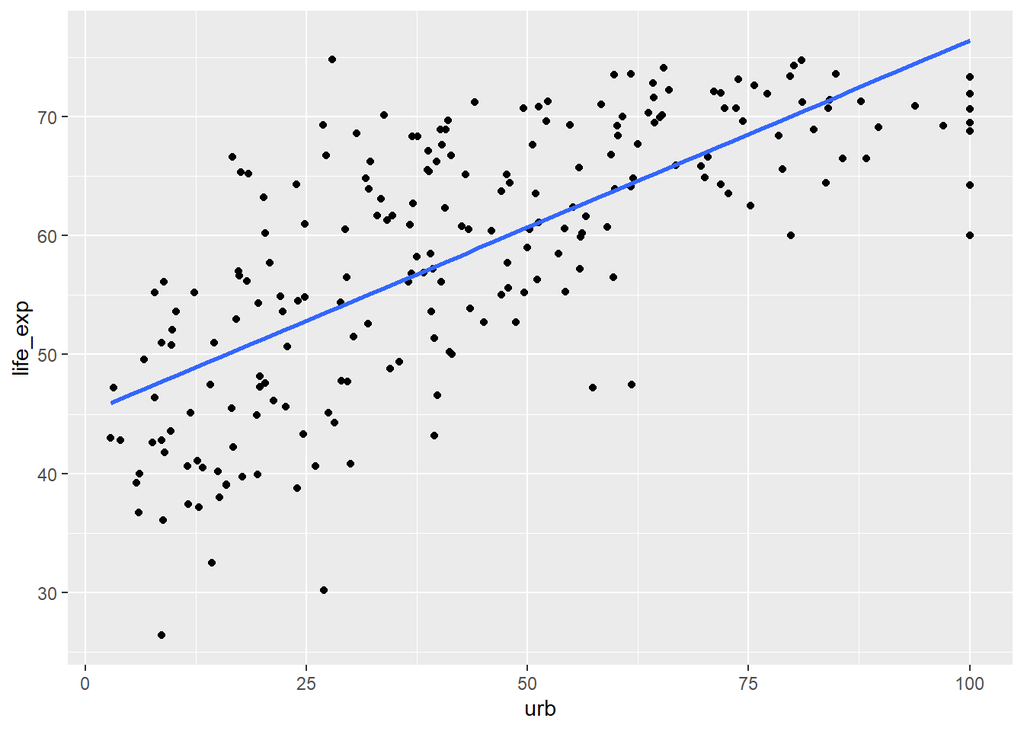

```r
library("ggplot2")
library("ggthemes")
library("dplyr")

#Setting path
setwd("C:/Users/Sofija/Desktop/Computational Methods/Week4/Data")
#Step1: Loading the data
life_expectancy <- read.csv(file = './life-expectancy.csv')
urbanization <- read.csv(file = './share-of-population-urban.csv')
#Step2: Removing empty strings
life_expectancy2<-subset(life_expectancy, Code!="")
#Step3: Changing variable name
names(life_expectancy2)[names(life_expectancy2)=="Life.expectancy.at.birth..historical."]<-"life_exp"
#Step4: Keeping only relevant vars
life_expectancy3<-subset(life_expectancy2, selec=c("Entity", "Code", "Year", "life_exp"))
#Step5: Removing empty strings
urbanization2<-subset(urbanization, Code!="")
#Step6: Changing variable name
names(urbanization2)[names(urbanization2)=="Urban.population....of.total.population."]<-"urb"
#Step7: Keeping only relevant vars
urbanization3<-subset(urbanization2, selec=c("Code", "Year", "urb"))
#Step8: Performing a merge
final<-left_join(life_expectancy3, urbanization3, by = c("Code"="Code",
                                                         "Year"="Year"))
#Step9: Removing NAs
final2<-final[complete.cases(final), ]
# Defining a subset within the dataset that will be showing just 1970
final_1970<-subset(final2, Year==1970)
# Creating the graph
ggplot(data = final_1970,
# Assigning the axes
  mapping = aes(x=urb,
                y=life_exp))+
  geom_point()+
  geom_smooth(method = "lm", se= FALSE)
```

# 6 Question 6

Now do the same for 2000

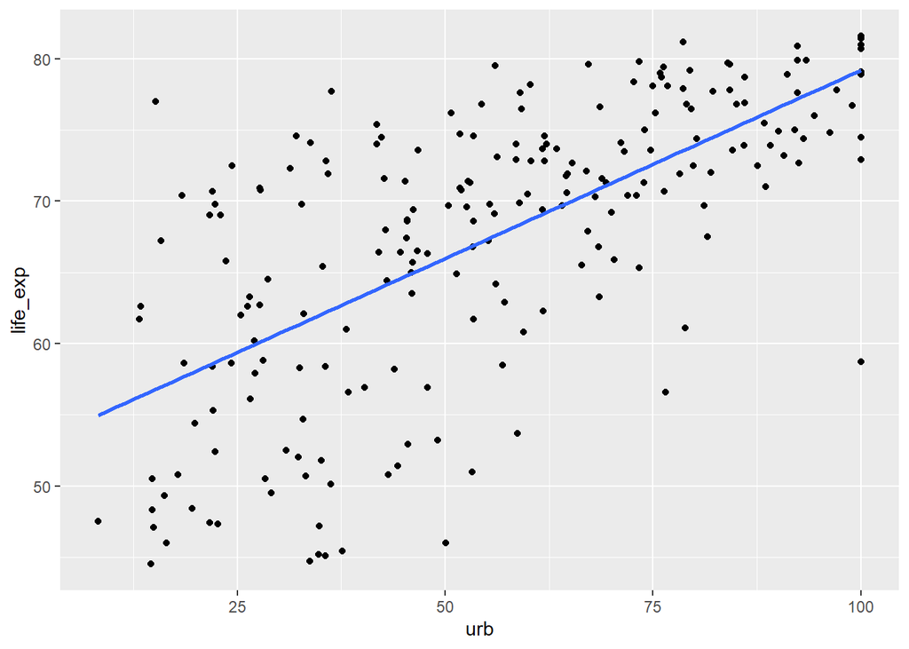

```r
# Defining a subset within the dataset that will be showing just 2000
final_2000<-subset(final2, Year==2000)
ggplot(data = final_2000,
  mapping = aes(x=urb,
                y=life_exp))+
  geom_point()+
  geom_smooth(method = "lm", se= FALSE)
```

# 7 Question 7

Now animate the graph to produce something like below.

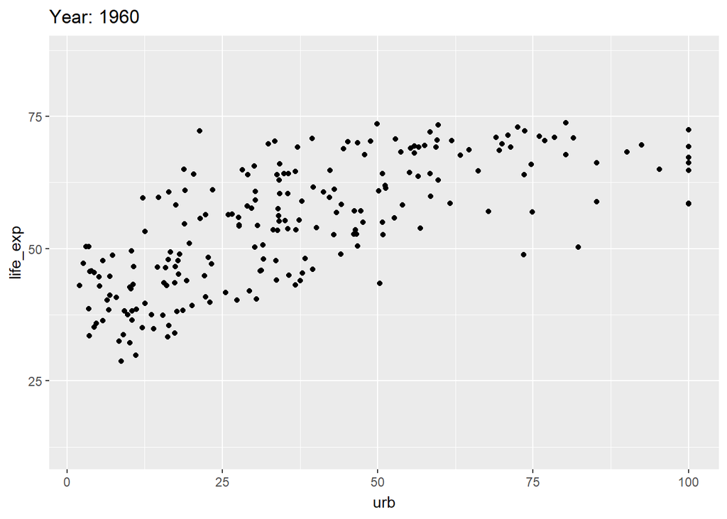

```r
library(gganimate)

ggplot(data = final2,
  mapping = aes(x=urb,
                y=life_exp))+
  geom_point()+
  labs(title = 'Year: {frame_time}',
       x = 'urb',
       y = 'life_exp')+
  transition_time(Year) +
  ease_aes('linear')
```

# 8 Question 8

What can you say about the relationship between urbanization and life expectancy over time. Write 5 sentences.

```r
# Overall, there has always been a positive relationship between urbanization and life expectancy. Both life expectancy and urbanization have been increasing from 1960 to 2021.The standard deviation was lower until around 1980, and then again from around 2015, while between those two years it was higher (which might indicate that the correlation between the two was weaker during the period). Over time, life expectancy has gone up in less urbanized countries also. In some less urbanized countries, life expectancy has been under 25 years before the 21st century, while in the most urbanized countries it went over 85 years in the last years.
```

# 9 Question 9

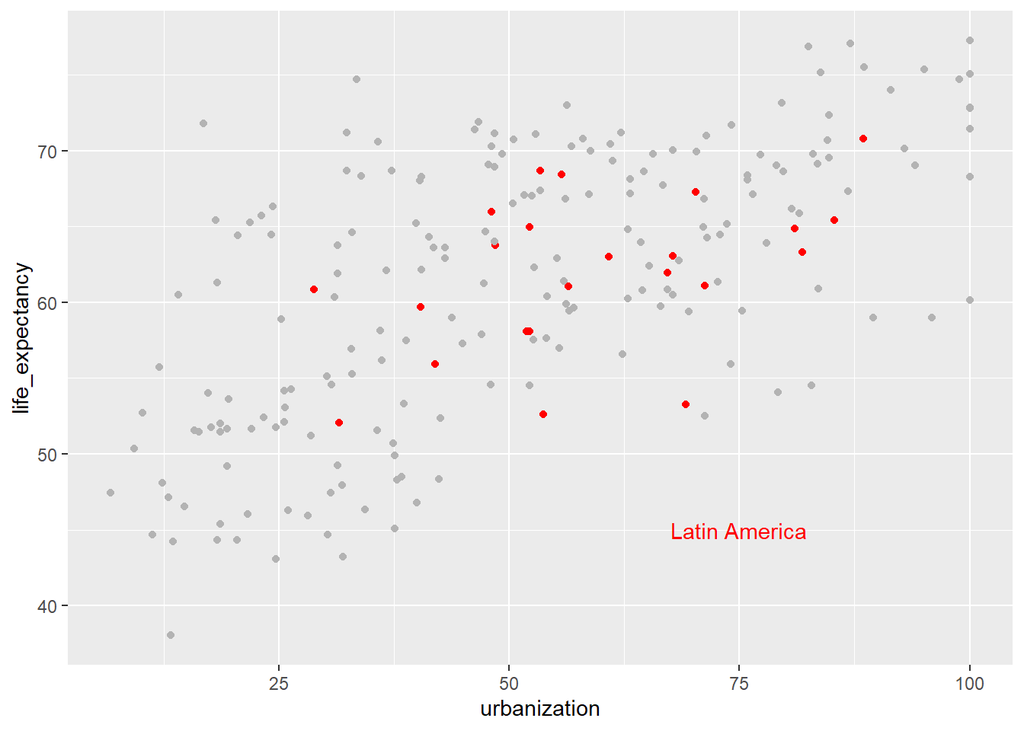

```r
setwd("C:/Users/Sofija/Desktop/Computational Methods/Week4/Data")
life_exp_urb <- read.csv(file = './life_exp_urb.csv')
#Creating a Variable to Identify Obs
life_exp_urb$LA <-ifelse(life_exp_urb$type=="Latin America", 1, 0)
#Making the variable a factor
life_exp_urb$LA<-as.factor(life_exp_urb$LA)
# Creating the graph
ggplot(data = life_exp_urb,
  mapping = aes(x=urbanization,
                y=life_expectancy,
# Indicating that Latin American countries should be in color
                color=LA))+
    geom_point()+
# Choosing the colors of dots
  scale_color_manual(values = c("grey70",
                                "red"))+
  guides(color = "none")+
# Creating red text "Latin America" in the graph
  annotate(geom = "text",
           x = 75, y = 45,
           label = "Latin America", color="red")
```

# 10 Question 10

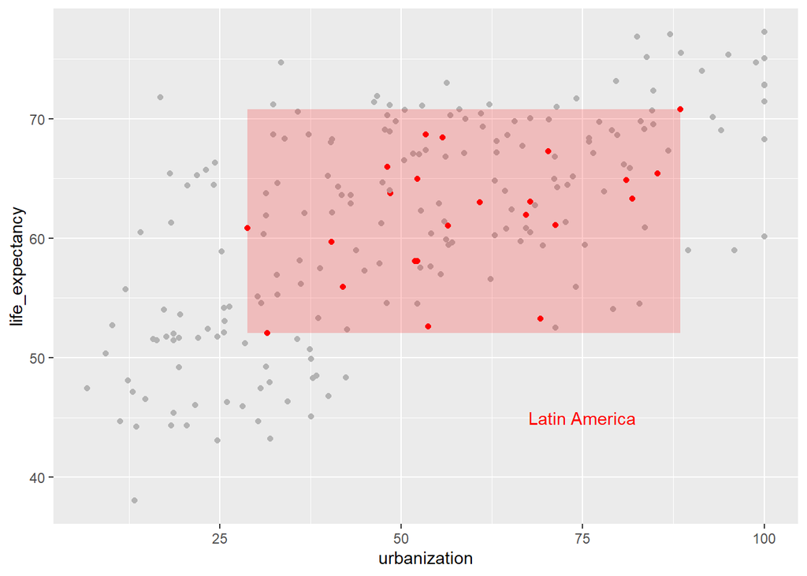

```r
# Creating a dummy variable within the data set that will have value 1 if the country is in Latin America
life_exp_urb$LA <-ifelse(life_exp_urb$type=="Latin America", 1, 0)
# Assigning the following variables to the overall minimum and maximum values of the Latin American countries
xmin_val<-min(life_exp_urb$urbanization[life_exp_urb$LA==1])
xmax_val<-max(life_exp_urb$urbanization[life_exp_urb$LA==1])
ymin_val<-min(life_exp_urb$life_expectancy[life_exp_urb$LA==1])
ymax_val<-max(life_exp_urb$life_expectancy[life_exp_urb$LA==1])
#Making the variable a factor
life_exp_urb$LA<-as.factor(life_exp_urb$LA)
# Creating graph
ggplot(data = life_exp_urb,
  mapping = aes(x=urbanization,
                y=life_expectancy,
                color=LA))+
    geom_point()+
  scale_color_manual(values = c("grey70",
                                "red"))+
  guides(color = "none")+
  annotate(geom = "text",
           x = 75, y = 45,
           label = "Latin America", color="red")+
  # Creating a red transparent rectangle that will stretch from the least to the most urbanized countries in Latin America on the x-axis and from the lowest to the highest life expectancy on the y-axis
  annotate(geom = "rect",
           xmin = xmin_val,
           xmax = xmax_val,
           ymin = ymin_val,
           ymax = ymax_val,
           fill = "red", alpha = 0.2)
```

# 11 Question 11

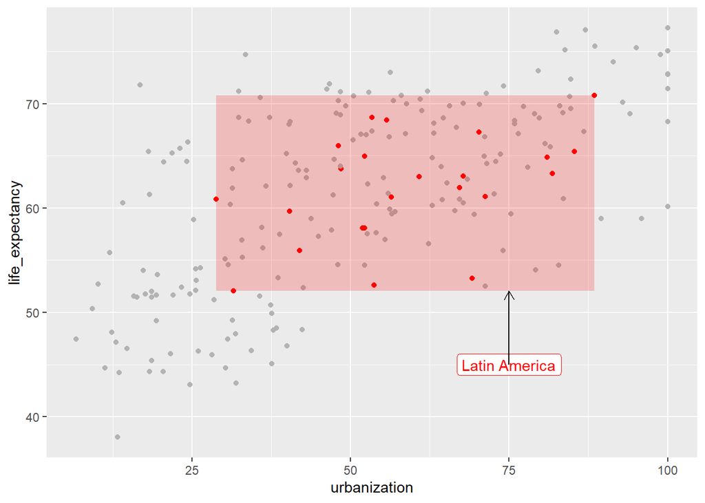

```r
life_exp_urb$LA <-ifelse(life_exp_urb$type=="Latin America", 1, 0)

xmin_val<-min(life_exp_urb$urbanization[life_exp_urb$LA==1])
xmax_val<-max(life_exp_urb$urbanization[life_exp_urb$LA==1])
ymin_val<-min(life_exp_urb$life_expectancy[life_exp_urb$LA==1])
ymax_val<-max(life_exp_urb$life_expectancy[life_exp_urb$LA==1])

life_exp_urb$LA<-as.factor(life_exp_urb$LA)
ggplot(data = life_exp_urb,
  mapping = aes(x=urbanization,
                y=life_expectancy,
                color=LA))+
    geom_point()+
  scale_color_manual(values = c("grey70",
                                "red"))+
  guides(color = "none")+
  annotate(geom = "label",
           x = 75, y = 45,
           label = "Latin America", color="red")+
  annotate(geom = "rect",
           xmin = xmin_val,
           xmax = xmax_val,
           ymin = ymin_val,
           ymax = ymax_val,
           fill = "red", alpha = 0.2)+
  # Creating an arrow that will point to the rectangle
  annotate(geom = "segment",
           x = 75,
           xend = 75,
           y = 45,
           yend = ymin_val,
           arrow = arrow(
             length = unit(0.1, "in")))
```